# Projet Aanlyse de Données

Med.Amairi

17/06/2020

# Importer et explorer mon BD :

```r
library(FactoMineR)
library("readxl")
df <- read_excel("AD.xlsx")
df=df[,2:41]
dim(df)
```

```
## [1] 78 40
```

```r
head(df)
```

| Quel est votre age ? | Genre: | De quelle region vous êtes ? | Vous êtes : | Catégorie socio professionnelle: | Habituellement, vous allez au café: | Vous allez au café: | Lorsque vous allez au café vous passez: | Quel est votre budget moyen pour les cafés par semaine ? | Vous allez au café avec: | Vous préférez d'aller au : | Lorsque vous êtes au café vous préférez parler du : [Sport] | Lorsque vous êtes au café vous préférez parler du : [Politique ] | Lorsque vous êtes au café vous préférez parler du : [Sujets sociaux] | Lorsque vous êtes au café vous préférez parler du : [Vie privé] | Lorsque vous êtes au café vous préférez parler du : [Vie profissionnelle] | Lorsque vous êtes au café, c'est pour ? [Fumer la chicha ] | Lorsque vous êtes au café, c'est pour ? [Envie de boire des boissons] | Lorsque vous êtes au café, c'est pour ? [Jouer aux cartes ] | Lorsque vous êtes au café, c'est pour ? [Regarder un match de foot] | Lorsque vous êtes au café, c'est pour ? [Etudier et reviser ] | Lorsque vous êtes au café, c'est pour ? [Travailler ] | Lorsque vous êtes au café, c'est pour ? [Discuter avec des amies ] | Lorsque vous êtes au café, c'est pour ? [Lire un journal ou une revue] | Lorsque vous êtes au café, c'est pour ? [Aller sur Internet] | Lorsque vous êtes au café, c'est pour ? [Organiser une fête d’amis] | Lorsque vous êtes au café, c'est pour ? [Ne rien à faire ] | Critères de choix du café: [ WIFI ] | Critères de choix du café: [Tarifs acceptable] | Critères de choix du café: [Le confort ] | … |
| --- | --- | --- | --- | --- | --- | --- | --- | --- | --- | --- | --- | --- | --- | --- | --- | --- | --- | --- | --- | --- | --- | --- | --- | --- | --- | --- | --- | --- | --- | --- |
| 23 | male | Nabeul | Célibataire | Etudiant | Chaque jour | Plus de deux fois par jour | Plus de deux heures | 30 | Des collégues, Des amies | café mixte | 2 | 2 | 5 | 4 | 4 | 5 | 3 | 3 | 1 | 4 | 4 | 5 | 1 | 3 | 4 | 2 | 4 | 5 | 5 | … |
| 19 | male | Tataouine | Célibataire | Etudiant | Quelques jours par semaine | Plus de deux fois par jour | Entre une heure et deux heures | 3000 | Des amies | Café | 3 | 3 | 3 | 3 | 3 | 1 | 3 | 2 | 3 | 1 | 4 | 4 | 3 | 3 | 3 | 3 | 3 | 5 | 5 | … |
| 20 | male | Tataouine | Célibataire | Etudiant | Le Weekend | Le soir | Entre une heure et deux heures | 3000 | Des amies | Café | 4 | 1 | 5 | 2 | 3 | 1 | 2 | 3 | 2 | 1 | 1 | 2 | 1 | 1 | 1 | 1 | 5 | 5 | 5 | … |
| 18 | male | Tataouine | Célibataire | Etudiant | Quelques jours par semaine | Plus de deux fois par jour | Entre une heure et deux heures | 2 | Des amies | Café | 5 | 3 | 3 | 2 | 2 | 4 | 3 | 3 | 4 | 1 | 1 | 4 | 2 | 4 | 1 | 1 | 5 | 3 | 5 | … |
| 23 | male | Le Kef | Célibataire | Etudiant | Quelques jours par semaine | Le soir | Entre une heure et deux heures | 4 | Des collégues | Café | 3 | 3 | 3 | 1 | 2 | 3 | 3 | 3 | 4 | 1 | 1 | 4 | 1 | 2 | 1 | 1 | 3 | 4 | 4 | … |
| 21 | female | Kairouan | Célibataire | Etudiant | Le Weekend | Le matin | Plus de deux heures | 10 | La famille, Des collégues, Des amies | Salon de thé | 3 | 2 | 4 | 4 | 4 | 1 | 1 | 4 | 2 | 4 | 3 | 5 | 2 | 2 | 4 | 2 | 4 | 4 | 4 | … |

```r
tail(df)
```

| Quel est votre age ? | Genre: | De quelle region vous êtes ? | Vous êtes : | Catégorie socio professionnelle: | Habituellement, vous allez au café: | Vous allez au café: | Lorsque vous allez au café vous passez: | Quel est votre budget moyen pour les cafés par semaine ? | Vous allez au café avec: | Vous préférez d'aller au : | Lorsque vous êtes au café vous préférez parler du : [Sport] | Lorsque vous êtes au café vous préférez parler du : [Politique ] | Lorsque vous êtes au café vous préférez parler du : [Sujets sociaux] | Lorsque vous êtes au café vous préférez parler du : [Vie privé] | Lorsque vous êtes au café vous préférez parler du : [Vie profissionnelle] | Lorsque vous êtes au café, c'est pour ? [Fumer la chicha ] | Lorsque vous êtes au café, c'est pour ? [Envie de boire des boissons] | Lorsque vous êtes au café, c'est pour ? [Jouer aux cartes ] | Lorsque vous êtes au café, c'est pour ? [Regarder un match de foot] | Lorsque vous êtes au café, c'est pour ? [Etudier et reviser ] | Lorsque vous êtes au café, c'est pour ? [Travailler ] | Lorsque vous êtes au café, c'est pour ? [Discuter avec des amies ] | Lorsque vous êtes au café, c'est pour ? [Lire un journal ou une revue] | Lorsque vous êtes au café, c'est pour ? [Aller sur Internet] | Lorsque vous êtes au café, c'est pour ? [Organiser une fête d’amis] | Lorsque vous êtes au café, c'est pour ? [Ne rien à faire ] | Critères de choix du café: [ WIFI ] | Critères de choix du café: [Tarifs acceptable] | Critères de choix du café: [Le confort ] | … |
| --- | --- | --- | --- | --- | --- | --- | --- | --- | --- | --- | --- | --- | --- | --- | --- | --- | --- | --- | --- | --- | --- | --- | --- | --- | --- | --- | --- | --- | --- | --- |
| 45 | female | Médnine | Marié | Chômeur | Les jours fériés | Le matin | Entre une heure et deux heures | 5 | La famille | Salon de thé | 1 | 1 | 4 | 4 | 1 | 1 | 4 | 1 | 1 | 1 | 1 | 4 | 1 | 2 | 1 | 2 | 2 | 4 | 5 | … |
| 22 | male | Grand Tunis | En couple | Etudiant | Quelques jours par semaine | Le soir | Moins d'une heure | 10 | La famille, Des amies | café mixte | 5 | 2 | 4 | 3 | 3 | 1 | 4 | 1 | 3 | 1 | 1 | 5 | 1 | 2 | 4 | 1 | 4 | 5 | 4 | … |
| 21 | male | Gafsa | Célibataire | Etudiant | Les jours fériés | Le soir | Entre une heure et deux heures | 2 | Des amies | café mixte | 3 | 2 | 4 | 3 | 5 | 1 | 1 | 1 | 1 | 1 | 1 | 5 | 1 | 1 | 1 | 1 | 3 | 4 | 4 | … |
| 22 | female | Grand Tunis | Célibataire | Etudiant | Le Weekend | Le soir | Entre une heure et deux heures | 10 | Des amies | Salon de thé | 4 | 1 | 5 | 4 | 4 | 4 | 3 | 3 | 3 | 4 | 3 | 5 | 1 | 3 | 3 | 1 | 3 | 4 | 4 | … |
| 29 | male | Bizerte | Célibataire | Professionel | Le Weekend | Le soir | Entre une heure et deux heures | 10 | Des amies | Café | 4 | 3 | 4 | 4 | 4 | 4 | 4 | 4 | 4 | 1 | 1 | 3 | 1 | 1 | 1 | 1 | 3 | 4 | 4 | … |
| 23 | male | Nabeul | Célibataire | Etudiant | Chaque jour | Le soir | Entre une heure et deux heures | 10 | Des amies | Salon de thé | 5 | 3 | 5 | 5 | 5 | 4 | 5 | 4 | 5 | 4 | 3 | 5 | 1 | 4 | 3 | 2 | 5 | 5 | 5 | … |

```r
str(df)
```

```
## tibble [78 x 40] (S3: tbl_df/tbl/data.frame)
##  $ Quel est votre age ?                                                     : num [1:78] 23 19 20 18 23 21 20 22 22 21 ...
##  $ Genre:                                                                   : chr [1:78] "male" "male" "male" "male" ...
##  $ De quelle region vous êtes ?                                             : chr [1:78] "Nabeul" "Tataouine" "Tataouine" "Tataouine" ...
##  $ Vous êtes  :                                                             : chr [1:78] "Célibataire" "Célibataire" "Célibataire" "Célibataire" ...
##  $ Catégorie socio professionnelle:                                         : chr [1:78] "Etudiant" "Etudiant" "Etudiant" "Etudiant" ...
##  $ Habituellement, vous allez  au café:                                     : chr [1:78] "Chaque jour" "Quelques jours par semaine" "Le Weekend" "Quelques jours par semaine" ...
##  $ Vous allez  au café:                                                     : chr [1:78] "Plus de deux fois par jour" "Plus de deux fois par jour" "Le soir" "Plus de deux fois par jour" ...
##  $ Lorsque vous allez au café vous passez:                                  : chr [1:78] "Plus de deux heures" "Entre une heure et deux heures" "Entre une heure et deux heures" "Entre une heure et deux heures" ...
##  $ Quel est votre budget moyen pour les cafés par semaine ?                 : num [1:78] 30 3000 3000 2 4 10 2500 10 10 5 ...
##  $ Vous allez au café avec:                                                 : chr [1:78] "Des collégues, Des amies" "Des amies" "Des amies" "Des amies" ...
##  $ Vous préférez d'aller au :                                               : chr [1:78] "café mixte" "Café" "Café" "Café" ...
##  $ Lorsque vous êtes au café vous préférez parler du : [Sport]              : num [1:78] 2 3 4 5 3 3 2 1 2 5 ...
##  $ Lorsque vous êtes au café vous préférez parler du : [Politique ]         : num [1:78] 2 3 1 3 3 2 2 3 2 1 ...
##  $ Lorsque vous êtes au café vous préférez parler du : [Sujets sociaux]     : num [1:78] 5 3 5 3 3 4 4 4 4 1 ...
```

[output cut: 26 more lines]

```r
summary(df)
```

```
##  Quel est votre age ?    Genre:          De quelle region vous êtes ?
##  Min.   :17.00        Length:78          Length:78
##  1st Qu.:21.00        Class :character   Class :character
##  Median :22.00        Mode  :character   Mode  :character
##  Mean   :23.29
##  3rd Qu.:23.00
##  Max.   :52.00
##  Vous êtes  :       Catégorie socio professionnelle:
##  Length:78          Length:78
##  Class :character   Class :character
##  Mode  :character   Mode  :character
##
##
##
##  Habituellement, vous allez  au café: Vous allez  au café:
##  Length:78                            Length:78
##  Class :character                     Class :character
##  Mode  :character                     Mode  :character
##
##
##
##  Lorsque vous allez au café vous passez:
##  Length:78
##  Class :character
##  Mode  :character
##
##
##
##  Quel est votre budget moyen pour les cafés par semaine ?
##  Min.   :   0.0
##  1st Qu.:   5.0
##  Median :  10.0
##  Mean   : 284.8
##  3rd Qu.:  20.0
##  Max.   :5000.0
##  Vous allez au café avec: Vous préférez d'aller au :
##  Length:78                Length:78
##  Class :character         Class :character
##  Mode  :character         Mode  :character
##
```

[output cut: 190 more lines]

```
##  Max.   :5.00
##  Critères de choix du café: [Café branché]
##  Min.   :1.000
##  1st Qu.:3.000
##  Median :3.000
##  Mean   :3.256
##  3rd Qu.:4.000
##  Max.   :5.000
##  Considère vous que l'aller au café est une habitude quotidienne ?
##  Min.   :1.000
##  1st Qu.:2.000
##  Median :3.000
##  Mean   :2.974
##  3rd Qu.:4.000
##  Max.   :5.000
```

## 1. Calul de la matrice centrée reduite :

## Centrer et réduire la matrice $X$:

```r
X=as.matrix(df[,17:27])
g=colMeans(X)
Y=sweep(x = X,2,g,FUN = '-')
round(colMeans(X),3)
```

```
##             Lorsque vous êtes au café, c'est pour ? [Fumer la chicha ]
##                                                                  1.846
##  Lorsque vous êtes au café, c'est pour ? [Envie de boire des boissons]
##                                                                  2.923
##            Lorsque vous êtes au café, c'est pour ? [Jouer aux cartes ]
##                                                                  2.551
##    Lorsque vous êtes au café, c'est pour ? [Regarder un match de foot]
##                                                                  2.731
##          Lorsque vous êtes au café, c'est pour ? [Etudier et reviser ]
##                                                                  2.692
##                  Lorsque vous êtes au café, c'est pour ? [Travailler ]
##                                                                  2.282
##     Lorsque vous êtes au café, c'est pour ? [Discuter avec des amies ]
##                                                                  4.244
## Lorsque vous êtes au café, c'est pour ? [Lire un journal ou une revue]
##                                                                  2.256
##           Lorsque vous êtes au café, c'est pour ? [Aller sur Internet]
##                                                                  2.987
##    Lorsque vous êtes au café, c'est pour ? [Organiser une fête d’amis]
##                                                                  2.679
##             Lorsque vous êtes au café, c'est pour ? [Ne rien à faire ]
##                                                                  2.231
```

## Calcul des écarts-types pour réduire les variables:

```r
n=nrow(X)
p=ncol(X)
et=apply(Y,2,function(x) sqrt(sum(x^2)/n))
et
```

```
##             Lorsque vous êtes au café, c'est pour ? [Fumer la chicha ]
##                                                              1.2616323
##  Lorsque vous êtes au café, c'est pour ? [Envie de boire des boissons]
##                                                              1.2379598
##            Lorsque vous êtes au café, c'est pour ? [Jouer aux cartes ]
##                                                              1.2674165
##    Lorsque vous êtes au café, c'est pour ? [Regarder un match de foot]
##                                                              1.4559610
##          Lorsque vous êtes au café, c'est pour ? [Etudier et reviser ]
##                                                              1.4876215
##                  Lorsque vous êtes au café, c'est pour ? [Travailler ]
##                                                              1.3097018
##     Lorsque vous êtes au café, c'est pour ? [Discuter avec des amies ]
##                                                              0.9498434
## Lorsque vous êtes au café, c'est pour ? [Lire un journal ou une revue]
##                                                              1.2448447
##           Lorsque vous êtes au café, c'est pour ? [Aller sur Internet]
##                                                              1.2859556
##    Lorsque vous êtes au café, c'est pour ? [Organiser une fête d’amis]
##                                                              1.3727531
##             Lorsque vous êtes au café, c'est pour ? [Ne rien à faire ]
##                                                              1.3389919
```

## Calcul de la matrice des données centrées réduites $Z$. On vérifie que les variables de cette matrice sont bien de variance égale à 1:

```r
Z=sweep(x = Y,2,et,FUN = '/')
colSums(Z^2)/n
```

```
##             Lorsque vous êtes au café, c'est pour ? [Fumer la chicha ]
##                                                                      1
##  Lorsque vous êtes au café, c'est pour ? [Envie de boire des boissons]
##                                                                      1
##            Lorsque vous êtes au café, c'est pour ? [Jouer aux cartes ]
##                                                                      1
##    Lorsque vous êtes au café, c'est pour ? [Regarder un match de foot]
##                                                                      1
##          Lorsque vous êtes au café, c'est pour ? [Etudier et reviser ]
##                                                                      1
##                  Lorsque vous êtes au café, c'est pour ? [Travailler ]
##                                                                      1
##     Lorsque vous êtes au café, c'est pour ? [Discuter avec des amies ]
##                                                                      1
## Lorsque vous êtes au café, c'est pour ? [Lire un journal ou une revue]
##                                                                      1
##           Lorsque vous êtes au café, c'est pour ? [Aller sur Internet]
##                                                                      1
##    Lorsque vous êtes au café, c'est pour ? [Organiser une fête d’amis]
##                                                                      1
##             Lorsque vous êtes au café, c'est pour ? [Ne rien à faire ]
##                                                                      1
```

## 2. Calcul de la matrice des corrélations:

## Calcul de la matrice des corrélations $R=Z'DZ$, ses valeurs propres et ses vecteurs propres.

```r
M=diag(rep(1,p))
D=(1/n)*diag(rep(1,n))
R=t(Z)%*%D%*%Z
vp=eigen(R %*%M)
lambda=vp$values
lambda
```

```
##  [1] 2.9805903 1.8185234 1.2264738 1.1097309 0.8872420 0.7843241 0.5769453
##  [8] 0.5014380 0.4582364 0.3897603 0.2667355
```

```r
U=vp$vectors
U
```

```
##            [,1]        [,2]        [,3]        [,4]        [,5]        [,6]
##  [1,] 0.1142968 -0.57866975  0.01055374  0.02831260 -0.37613053 -0.05561353
##  [2,] 0.1016148 -0.31425049 -0.60162737  0.19073406  0.18712386 -0.38652497
##  [3,] 0.3143452 -0.40807035  0.17809918 -0.04858676 -0.24712864  0.11879321
##  [4,] 0.1872872 -0.47118445 -0.05498424 -0.31952281  0.29644003  0.24087370
##  [5,] 0.4146296  0.18462195  0.28051796 -0.23769691 -0.13874188 -0.29426754
##  [6,] 0.4279308  0.14076386  0.18327945  0.09485279 -0.29844880 -0.33588313
##  [7,] 0.1340347  0.23018294 -0.57667267 -0.31210513 -0.43086019  0.33782638
##  [8,] 0.3993677  0.02339653  0.07004209  0.04496369  0.58496825 -0.01543641
##  [9,] 0.3824691  0.12928067  0.05359053  0.04212161  0.11789953  0.60331668
## [10,] 0.3677258  0.23095974 -0.38259004 -0.06070209  0.08800936 -0.21554852
## [11,] 0.1694525  0.01909311 -0.06484220  0.82944332 -0.12948332  0.22615401
##              [,7]        [,8]        [,9]       [,10]       [,11]
##  [1,]  0.26911628  0.22512831 -0.45760769  0.33186828 -0.25288311
##  [2,]  0.39605639 -0.12101439  0.31492771 -0.17580270  0.08110485
##  [3,] -0.23997650 -0.65659600 -0.01632428 -0.28456605  0.23547818
##  [4,] -0.39989260  0.41499975  0.39091254  0.07725595 -0.03120608
##  [5,]  0.14865277 -0.08622564  0.36057643 -0.05691557 -0.62464147
##  [6,] -0.01641821  0.46247395  0.05799177 -0.09585049  0.57085997
##  [7,] -0.03588084  0.14924426 -0.13412135 -0.37906223 -0.11867761
##  [8,]  0.03089088  0.09775472 -0.55478812 -0.39529268 -0.12668040
##  [9,]  0.54343398 -0.08480017  0.15524115  0.30105064  0.19293406
## [10,] -0.38269226 -0.24652662 -0.18220485  0.60493034  0.02829435
## [11,] -0.29466967  0.10107602  0.14792369 -0.05538198 -0.29805009
```

## Vérifions que les vecteurs propres (i.e. les colonnes de $U$) sont bien orthornormés:

```r
round(t(U)%*%U,3)
```

```
##       [,1] [,2] [,3] [,4] [,5] [,6] [,7] [,8] [,9] [,10] [,11]
##  [1,]    1    0    0    0    0    0    0    0    0     0     0
##  [2,]    0    1    0    0    0    0    0    0    0     0     0
##  [3,]    0    0    1    0    0    0    0    0    0     0     0
##  [4,]    0    0    0    1    0    0    0    0    0     0     0
##  [5,]    0    0    0    0    1    0    0    0    0     0     0
##  [6,]    0    0    0    0    0    1    0    0    0     0     0
##  [7,]    0    0    0    0    0    0    1    0    0     0     0
##  [8,]    0    0    0    0    0    0    0    1    0     0     0
##  [9,]    0    0    0    0    0    0    0    0    1     0     0
## [10,]    0    0    0    0    0    0    0    0    0     1     0
## [11,]    0    0    0    0    0    0    0    0    0     0     1
```

## 3.Les composantes principales:

## Calculons la matrice $Psi$ des composantes principales qui est donnée par $Psi=Zu$. On verifiera que la variance de chaque composante est égale à la valeur propore correspondante:

```r
Psi=Z%*%U
Psi
```

```
##              [,1]        [,2]        [,3]         [,4]        [,5]
##  [1,]  1.13849112 -0.32365334 -0.28183419 -0.134120104 -2.70732244
##  [2,]  0.30840300  0.45468724 -0.14711833  0.919381543  0.59980887
##  [3,] -2.94206461 -0.70058699  1.76995826  0.098116820  0.58290404
##  [4,] -0.83562714 -2.17261519  0.20057986 -0.642191386  0.08461385
##  [5,] -1.84187904 -1.93380792  0.05260158 -0.766262759 -0.27053354
##  [6,]  0.68526193  1.18389734  0.63407989 -0.858879688 -1.20238837
##  [7,] -1.93130250 -1.36892994  0.63276128 -0.799882362 -0.82170114
##  [8,] -0.75334701  1.65178326 -1.69960657 -0.476567504  0.93922791
##  [9,] -0.19060095  1.28096335 -0.46322528  1.656580937 -0.63799540
## [10,] -2.38731962 -1.71237047 -0.12959356 -0.760682587 -0.16722983
## [11,]  2.52517184  0.71600382 -0.40226518 -1.162918496  0.25651051
## [12,] -0.83018465  0.98953031  2.24671099  0.108404246 -0.90191875
## [13,] -0.29001196  0.57025061  1.13685692 -0.905205607  0.26363157
## [14,]  2.49952009  0.29145297  1.03226641  0.514352859 -0.10335975
```

[output cut: 222 more lines]

```r
round(t(Psi)%*%D%*%Psi,3)
```

```
##        [,1]  [,2]  [,3] [,4]  [,5]  [,6]  [,7]  [,8]  [,9] [,10] [,11]
##  [1,] 2.981 0.000 0.000 0.00 0.000 0.000 0.000 0.000 0.000  0.00 0.000
##  [2,] 0.000 1.819 0.000 0.00 0.000 0.000 0.000 0.000 0.000  0.00 0.000
##  [3,] 0.000 0.000 1.226 0.00 0.000 0.000 0.000 0.000 0.000  0.00 0.000
##  [4,] 0.000 0.000 0.000 1.11 0.000 0.000 0.000 0.000 0.000  0.00 0.000
##  [5,] 0.000 0.000 0.000 0.00 0.887 0.000 0.000 0.000 0.000  0.00 0.000
##  [6,] 0.000 0.000 0.000 0.00 0.000 0.784 0.000 0.000 0.000  0.00 0.000
##  [7,] 0.000 0.000 0.000 0.00 0.000 0.000 0.577 0.000 0.000  0.00 0.000
##  [8,] 0.000 0.000 0.000 0.00 0.000 0.000 0.000 0.501 0.000  0.00 0.000
##  [9,] 0.000 0.000 0.000 0.00 0.000 0.000 0.000 0.000 0.458  0.00 0.000
## [10,] 0.000 0.000 0.000 0.00 0.000 0.000 0.000 0.000 0.000  0.39 0.000
## [11,] 0.000 0.000 0.000 0.00 0.000 0.000 0.000 0.000 0.000  0.00 0.267
```

## 4.Les coordonnées des variables sur les axes :

## Calculons la matrice $Eta$ des coordonnées des variables sur les axes principaux par $Eta_\alpha = \sqrt{(\lambda_\alpha)} u_\alpha$:

```r
Eta<-sweep(U,2,sqrt(lambda),FUN='*')
Eta
```

```
##            [,1]        [,2]        [,3]        [,4]        [,5]        [,6]
##  [1,] 0.1973263 -0.78035143  0.01168788  0.02982556 -0.35429059 -0.04925249
##  [2,] 0.1754317 -0.42377508 -0.66627993  0.20092644  0.17625855 -0.34231453
##  [3,] 0.5426977 -0.55029363  0.19723821 -0.05118312 -0.23277917  0.10520573
##  [4,] 0.3233398 -0.63540467 -0.06089300 -0.33659736  0.27922731  0.21332274
##  [5,] 0.7158325  0.24896757  0.31066320 -0.25039887 -0.13068586 -0.26060943
##  [6,] 0.7387963  0.18982377  0.20297517  0.09992150 -0.28111944 -0.29746506
##  [7,] 0.2314026  0.31040777 -0.63864353 -0.32878329 -0.40584239  0.29918604
##  [8,] 0.6894837  0.03155084  0.07756901  0.04736645  0.55100219 -0.01367080
##  [9,] 0.6603094  0.17433839  0.05934952  0.04437249  0.11105372  0.53430976
## [10,] 0.6348560  0.31145530 -0.42370423 -0.06394587  0.08289911 -0.19089424
## [11,] 0.2925493  0.02574757 -0.07181032  0.87376682 -0.12196490  0.20028668
##              [,7]        [,8]        [,9]       [,10]       [,11]
##  [1,]  0.20441242  0.15941850 -0.30976912  0.20718798 -0.13060513
##  [2,]  0.30083221 -0.08569305  0.21318453 -0.10975501  0.04188777
##  [3,] -0.18227874 -0.46495062 -0.01105042 -0.17765682  0.12161611
##  [4,] -0.30374608  0.29387080  0.26462106  0.04823149 -0.01611683
##  [5,]  0.11291206 -0.06105834  0.24408559 -0.03553284 -0.32260511
##  [6,] -0.01247076  0.32748837  0.03925646 -0.05984022  0.29482887
##  [7,] -0.02725398  0.10568327 -0.09079098 -0.23665153 -0.06129276
##  [8,]  0.02346376  0.06922235 -0.37555363 -0.24678433 -0.06542592
##  [9,]  0.41277567 -0.06004894  0.10508765  0.18794828  0.09964358
## [10,] -0.29068123 -0.17457113 -0.12334023  0.37766277  0.01461302
## [11,] -0.22382199  0.07157424  0.10013422 -0.03457541 -0.15393227
```

# ACP normée avec le package FactoMineR et interprétation de l’ACP

## 1. Intérêt de l’ACP :

L’intérêt de cette ACP est double. En se basant sur les corrélations qui peuvent exister entre les variables, la méthode va les regrouper pour proposer un petit nombre de nouvelles variables et qui décrivent les habitudes de tunisiens lorsques ils vont au café.

## 2. Pertinence de l’ACP:

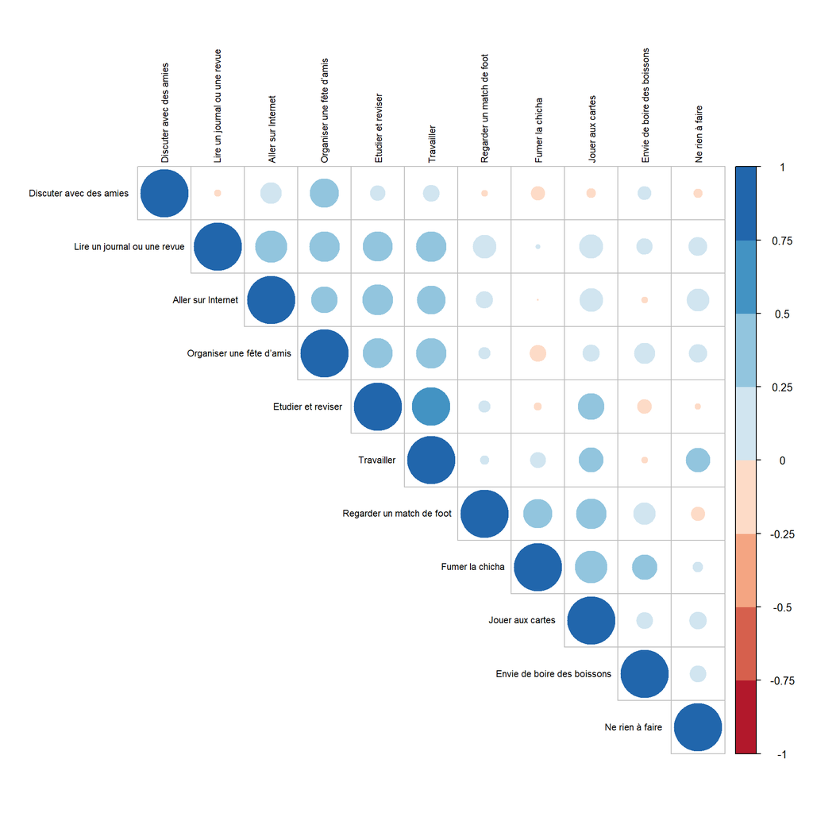

```r
library(corrplot)
X=as.matrix(df[,c(17:27)])
colnames(X) <- c("Fumer la chicha","Envie de boire des boissons","Jouer aux cartes ","Regarder un match de foot","Etudier et reviser ","Travailler ","Discuter avec des amies ","Lire un journal ou une revue","Aller sur Internet","Organiser une fête d’amis","Ne rien à faire ")
M<-cor(X)
library(RColorBrewer)
corrplot(M, type="upper",tl.cex = 0.7,tl.col = 'black', order="hclust",
         col=brewer.pal(n=8, name="RdBu"))
```

Le corrgram donné ci-dessus permet d’étudier les corrélations entre les variables quantitatives .

Par contre il n’y a pas des corrélations entre quelques variables en effet il n’existe pas une corrélation entre les gens qui vont au café pour travailler ou etudier et les gens qui vont au café pour regarder un match de foot .

```r
library(factoextra)
```

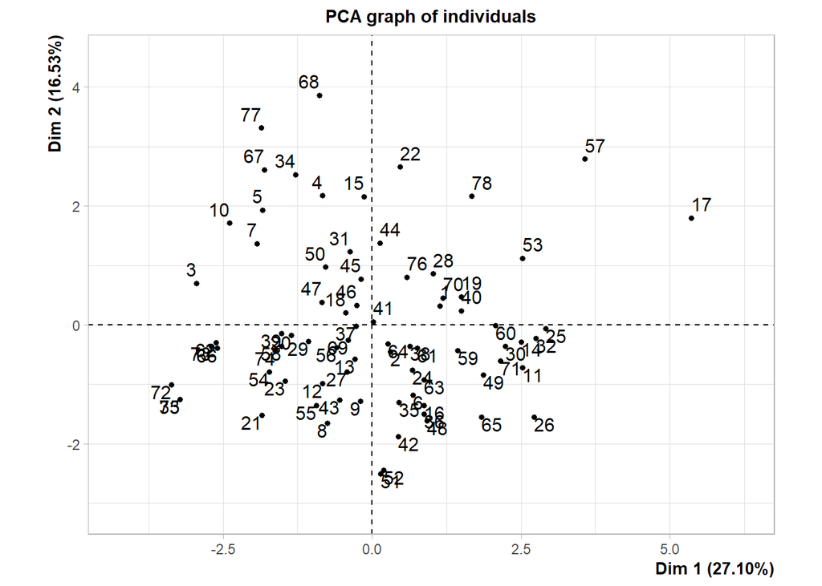

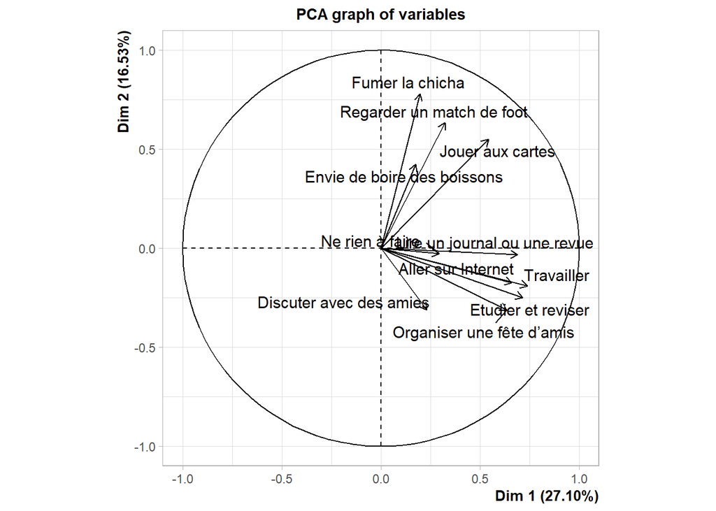

```r
df1=df[,17:27]
colnames(df1) <- c("Fumer la chicha","Envie de boire des boissons","Jouer aux cartes ","Regarder un match de foot","Etudier et reviser ","Travailler ","Discuter avec des amies ","Lire un journal ou une revue","Aller sur Internet","Organiser une fête d’amis","Ne rien à faire ")
res.pca=PCA(df1,scale.unit = TRUE,ncp =5,graph = T)
```

## 3. Choix du nombre d’axes à retenir:

```r
head(res.pca$eig)
```

```
##        eigenvalue percentage of variance cumulative percentage of variance
## comp 1  2.9805903              27.096276                          27.09628
## comp 2  1.8185234              16.532031                          43.62831
## comp 3  1.2264738              11.149762                          54.77807
## comp 4  1.1097309              10.088462                          64.86653
## comp 5  0.8872420               8.065836                          72.93237
## comp 6  0.7843241               7.130219                          80.06259
```

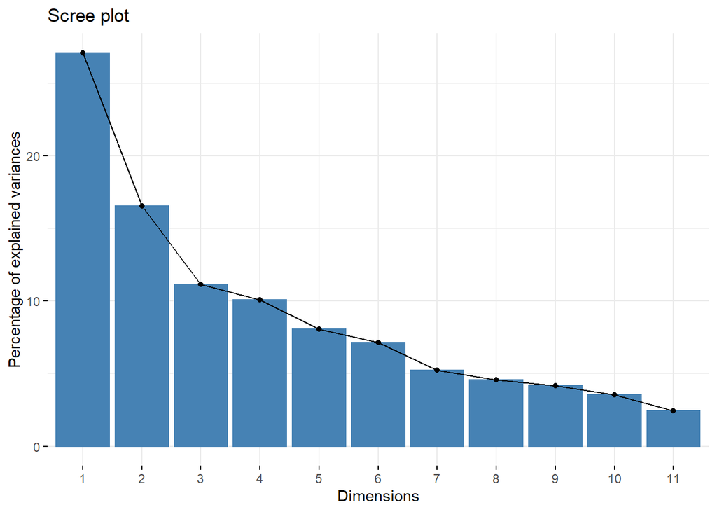

```r
fviz_screeplot(res.pca, ncp=11)
```

**a.Critère de kaiser :** on remarque qu’il y a 4 axes dont les valeurs propres sont supérieures à 1 donc on retient 4 axes d’après ce critère.

**c.Critère du coude :** On remarque que le coude se trouve au niveau du troisiéme axe , d’après ce critère, on devrait retenir les 3 premiers axes.

## 4. Interprétation de la carte des variables:

```r
round( res.pca$var$coord ,digits = 3)
```

```
##                              Dim.1  Dim.2  Dim.3  Dim.4  Dim.5
## Fumer la chicha              0.197  0.780 -0.012  0.030  0.354
## Envie de boire des boissons  0.175  0.424  0.666  0.201 -0.176
## Jouer aux cartes             0.543  0.550 -0.197 -0.051  0.233
## Regarder un match de foot    0.323  0.635  0.061 -0.337 -0.279
## Etudier et reviser           0.716 -0.249 -0.311 -0.250  0.131
## Travailler                   0.739 -0.190 -0.203  0.100  0.281
## Discuter avec des amies      0.231 -0.310  0.639 -0.329  0.406
## Lire un journal ou une revue 0.689 -0.032 -0.078  0.047 -0.551
## Aller sur Internet           0.660 -0.174 -0.059  0.044 -0.111
## Organiser une fête d’amis    0.635 -0.311  0.424 -0.064 -0.083
## Ne rien à faire              0.293 -0.026  0.072  0.874  0.122
```

```r
round(res.pca$var$cos2,digits = 3)
```

```
##                              Dim.1 Dim.2 Dim.3 Dim.4 Dim.5
## Fumer la chicha              0.039 0.609 0.000 0.001 0.126
## Envie de boire des boissons  0.031 0.180 0.444 0.040 0.031
## Jouer aux cartes             0.295 0.303 0.039 0.003 0.054
## Regarder un match de foot    0.105 0.404 0.004 0.113 0.078
## Etudier et reviser           0.512 0.062 0.097 0.063 0.017
## Travailler                   0.546 0.036 0.041 0.010 0.079
## Discuter avec des amies      0.054 0.096 0.408 0.108 0.165
## Lire un journal ou une revue 0.475 0.001 0.006 0.002 0.304
## Aller sur Internet           0.436 0.030 0.004 0.002 0.012
## Organiser une fête d’amis    0.403 0.097 0.180 0.004 0.007
## Ne rien à faire              0.086 0.001 0.005 0.763 0.015
```

### Axe 1 :

Cette axe est fortement corrélé aux variables (“Etudier et reviser”,“Travailler”,“Lire un journal ou une revue”,“Aller sur Internet”).En effet cet axe représente bien les individus qui vont au café pour des raisons **educatives** et **professionnelles** .

### Axe 2 :

Cette axe est fortement corrélé aux variables (“Fumer la chicha”,“Jouer aux cartes”,“Regarder un match de foot”),on peut dire que cette axe est trés proche **des habitudes quotidiennes des citoyens tunisiens dans les cafés**.

## Axe 3 :

Cette axe est corrélé aux variables (“Envie de boire des boissons”,“Discuter avec des amies”,“Organiser une fête d’amis”), cette axe en effet met en vidence que le café est un **espace social** pour **relaxer** et **amuser avec les amies**.

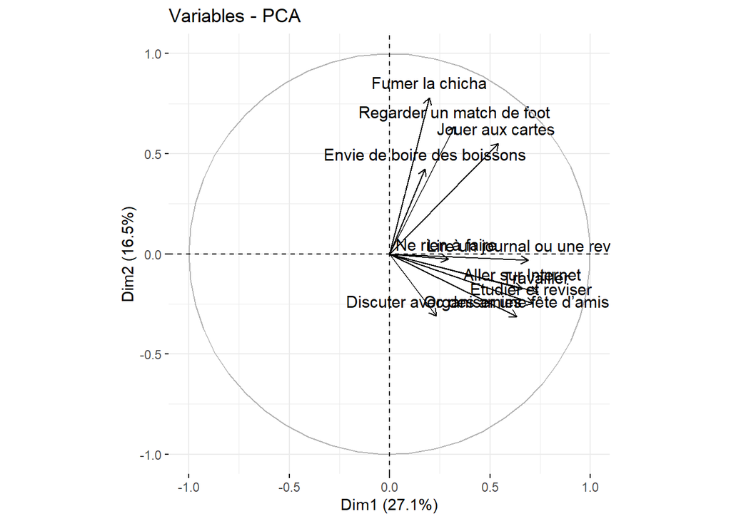

```r
fviz_pca_var(res.pca)
```

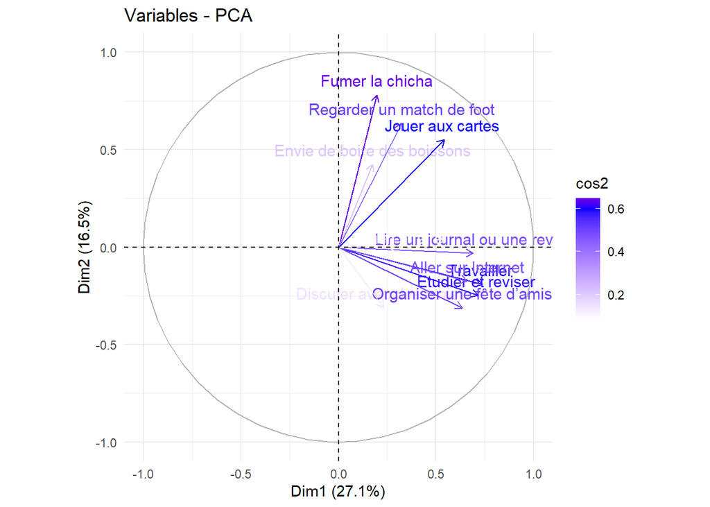

```r
fviz_pca_var(res.pca, col.var="cos2") +
  scale_color_gradient2(low="white", mid="blue",
                        high="red", midpoint=0.6) +
  theme_minimal()
```

## 5. Interprétation de la carte des individus:

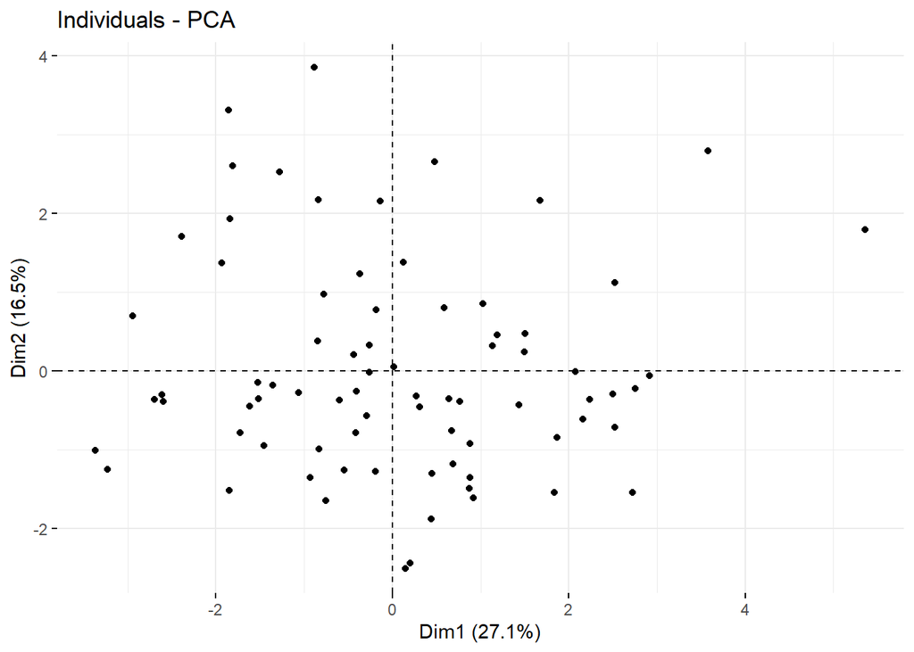

```r
fviz_pca_ind(res.pca,geom = "point",col.ind.sup = 'gray')
```

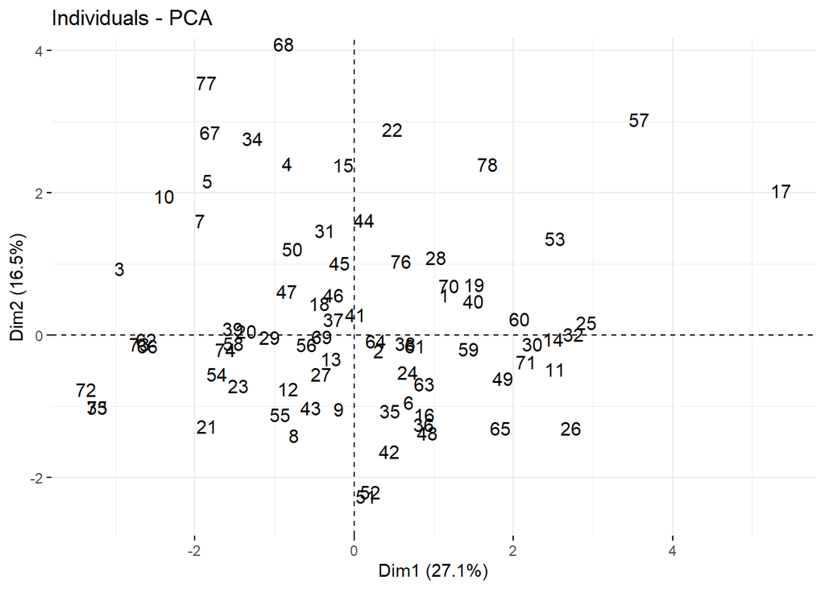

```r
fviz_pca_ind(res.pca,geom = "text",col.ind.sup = 'gray')
```

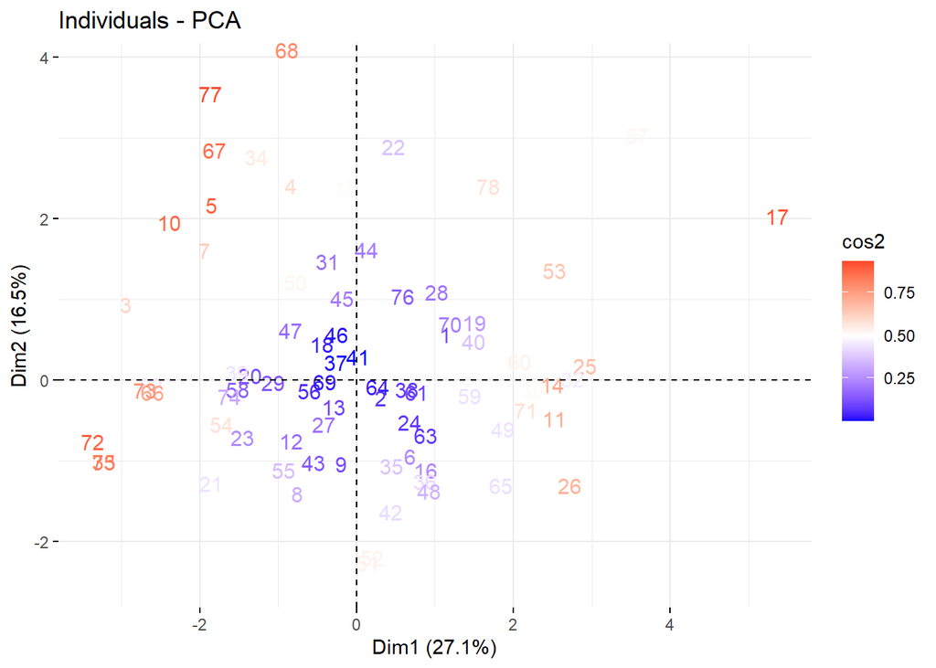

```r
fviz_pca_ind(res.pca,geom = "text",col.ind="cos2")+
scale_color_gradient2(low="blue", mid="white",
                      high="red", midpoint=0.5)
```

# Analyse Factorielle des Correspondances

Dans la partie AFC je choisis de travailler sur le variable “fréquentation au café par semaine” avec les modalités suivantes : **Chaque jour,Le Weekend,Les jours fériés,Quelques jours par semaine** et le variable “type de café” avec les modalités suivantes :**Salon de thé,Café,café mixte,Café bar,Café restaurant**.

## 1. Introduction de tableau:

```r
library("factoextra")
library(FactoMineR)
df2<-df[,6]
colnames(df2)<-c("fréquentation ")
head(df2)
```

| fréquentation |
| --- |
| Chaque jour |
| Quelques jours par semaine |
| Le Weekend |
| Quelques jours par semaine |
| Quelques jours par semaine |
| Le Weekend |

```r
df3<-df[,11]
colnames(df3)<-c("typecafé")
head(df3)
```

| typecafé |
| --- |
| café mixte |
| Café |
| Café |
| Café |
| Café |
| Salon de thé |

```r
don<-cbind.data.frame(df2,df3)
don
```

| fréquentation | typecafé |
| --- | --- |
| Chaque jour | café mixte |
| Quelques jours par semaine | Café |
| Le Weekend | Café |
| Quelques jours par semaine | Café |
| Quelques jours par semaine | Café |
| Le Weekend | Salon de thé |
| Le Weekend | Café |
| Le Weekend | Salon de thé |
| Quelques jours par semaine | Salon de thé |
| Le Weekend | Café |

[output cut: 68 more lines]

## 2.Tableau croisée des effectifs et des fréquences:

```r
tab<-table(don$fréquentation,don$typecafé)
tab
```

```
##
##                              Café Café bar café mixte Café restaurant
##   Chaque jour                   9        1          1               0
##   Le Weekend                    9        1          1               3
##   Les jours fériés              3        0          5               2
##   Quelques jours par semaine   10        0          8               0
##
##                              Salon de thé
##   Chaque jour                           2
##   Le Weekend                           10
##   Les jours fériés                      4
##   Quelques jours par semaine            9
```

```r
colnames(tab)<-c("café","cafébar","cafémx","caféres","salonthé")
addmargins(tab)
```

```
##
##                              café cafébar cafémx caféres salonthé Sum
##   Chaque jour                   9       1      1       0        2  13
##   Le Weekend                    9       1      1       3       10  24
##   Les jours fériés              3       0      5       2        4  14
##   Quelques jours par semaine   10       0      8       0        9  27
##   Sum                          31       2     15       5       25  78
```

```r
prop.table(tab)
```

```
##
##                                    café    cafébar     cafémx    caféres
##   Chaque jour                0.11538462 0.01282051 0.01282051 0.00000000
##   Le Weekend                 0.11538462 0.01282051 0.01282051 0.03846154
##   Les jours fériés           0.03846154 0.00000000 0.06410256 0.02564103
##   Quelques jours par semaine 0.12820513 0.00000000 0.10256410 0.00000000
##
##                                salonthé
##   Chaque jour                0.02564103
##   Le Weekend                 0.12820513
##   Les jours fériés           0.05128205
##   Quelques jours par semaine 0.11538462
```

```r
addmargins(prop.table(tab))
```

```
##
##                                    café    cafébar     cafémx    caféres
##   Chaque jour                0.11538462 0.01282051 0.01282051 0.00000000
##   Le Weekend                 0.11538462 0.01282051 0.01282051 0.03846154
##   Les jours fériés           0.03846154 0.00000000 0.06410256 0.02564103
##   Quelques jours par semaine 0.12820513 0.00000000 0.10256410 0.00000000
##   Sum                        0.39743590 0.02564103 0.19230769 0.06410256
##
##                                salonthé        Sum
##   Chaque jour                0.02564103 0.16666667
##   Le Weekend                 0.12820513 0.30769231
##   Les jours fériés           0.05128205 0.17948718
##   Quelques jours par semaine 0.11538462 0.34615385
##   Sum                        0.32051282 1.00000000
```

## 3.Tableaux des profils-lignes et profils-colonnes:

```r
library(questionr)
lprop(tab)
```

```
##
##                              café  cafébar cafémx caféres salonthé Total
##   Chaque jour                 69.2   7.7     7.7    0.0    15.4    100.0
##   Le Weekend                  37.5   4.2     4.2   12.5    41.7    100.0
##   Les jours fériés            21.4   0.0    35.7   14.3    28.6    100.0
##   Quelques jours par semaine  37.0   0.0    29.6    0.0    33.3    100.0
##   All                         39.7   2.6    19.2    6.4    32.1    100.0
```

Parmi ceux qui vont au café chaque jour 69.2% choisissent d’aller aux cafés simples et 23% choisissent les salons de thé et les cafés mixtes . De plus parmi qui vont au café les jours feriers par exemple 21.4% choisissent les cafés simples et 64.3% vont aux salon de thé et cafés mixtes .

```r
cprop(tab)
```

```
##
##                              café  cafébar cafémx caféres salonthé All
##   Chaque jour                 29.0  50.0     6.7    0.0     8.0     16.7
##   Le Weekend                  29.0  50.0     6.7   60.0    40.0     30.8
##   Les jours fériés             9.7   0.0    33.3   40.0    16.0     17.9
##   Quelques jours par semaine  32.3   0.0    53.3    0.0    36.0     34.6
##   Total                      100.0 100.0   100.0  100.0   100.0    100.0
```

Ainsi parmi qui préfernt les salons de thé 40% vont le weekend et 8% chaque jour ,et parmi qui préferent les cafés mixtes 53.3% vont quelques jours par semaine 33.3% les jours fériés et juste 6.6 % chaque jour .

La différence qui existe entre les profils colonnes et plus particulièrement entre ce profil et le profil moyen indique que cette AFC ne peut être que pertinente, chose qui sera confirmée par le test du chi-2 .

## 4.Test du chi-2:

```r
test<-chisq.test(tab)
test
```

```
##
##  Pearson's Chi-squared test
##
## data:  tab
## X-squared = 21.152, df = 12, p-value = 0.0482
```

## 5.Exécution de l’AFC :

```r
res.ca<-CA(tab,graph=F)
summary(res.ca)
```

```
##
## Call:
## CA(X = tab, graph = F)
##
## The chi square of independence between the two variables is equal to 21.15203 (p-value =  0.04819809 ).
##
## Eigenvalues
##                        Dim.1   Dim.2   Dim.3
## Variance               0.150   0.099   0.022
## % of var.             55.362  36.587   8.051
## Cumulative % of var.  55.362  91.949 100.000
##
## Rows
##                              Iner*1000    Dim.1    ctr   cos2    Dim.2    ctr
## Chaque jour                |    90.223 |  0.639 45.280  0.753 | -0.327 18.010
## Le Weekend                 |    66.456 |  0.219  9.804  0.221 |  0.402 50.092
## Les jours fériés           |    63.155 | -0.522 32.597  0.775 |  0.156  4.420
## Quelques jours par semaine |    51.345 | -0.231 12.320  0.360 | -0.281 27.478
##                              cos2    Dim.3    ctr   cos2
## Chaque jour                 0.198 |  0.162 20.044  0.049 |
## Le Weekend                  0.748 | -0.081  9.335  0.031 |
## Les jours fériés            0.069 |  0.234 45.035  0.156 |
## Quelques jours par semaine  0.531 | -0.127 25.587  0.109 |
##
## Columns
##                              Iner*1000    Dim.1    ctr   cos2    Dim.2    ctr
## café                       |    52.639 |  0.320 27.031  0.771 | -0.171 11.678
## cafébar                    |    33.654 |  1.106 20.906  0.933 |  0.118  0.361
## cafémx                     |    92.671 | -0.620 49.219  0.797 | -0.294 16.754
## caféres                    |    68.040 | -0.200  1.714  0.038 |  0.964 60.047
## salonthé                   |    24.176 | -0.073  1.130  0.070 |  0.186 11.160
##                              cos2    Dim.3    ctr   cos2
## café                        0.220 |  0.034  2.157  0.009 |
## cafébar                     0.011 |  0.273  8.748  0.057 |
## cafémx                      0.179 |  0.106  9.870  0.023 |
## caféres                     0.876 |  0.303 26.977  0.087 |
## salonthé                    0.458 | -0.189 52.248  0.472 |
```

## 6. Choix du nombre d’axes a retenir :

```r
eig.val <- res.ca$eig
round(res.ca$eig,3)
```

```
##       eigenvalue percentage of variance cumulative percentage of variance
## dim 1      0.150                 55.362                            55.362
## dim 2      0.099                 36.587                            91.949
## dim 3      0.022                  8.051                           100.000
```

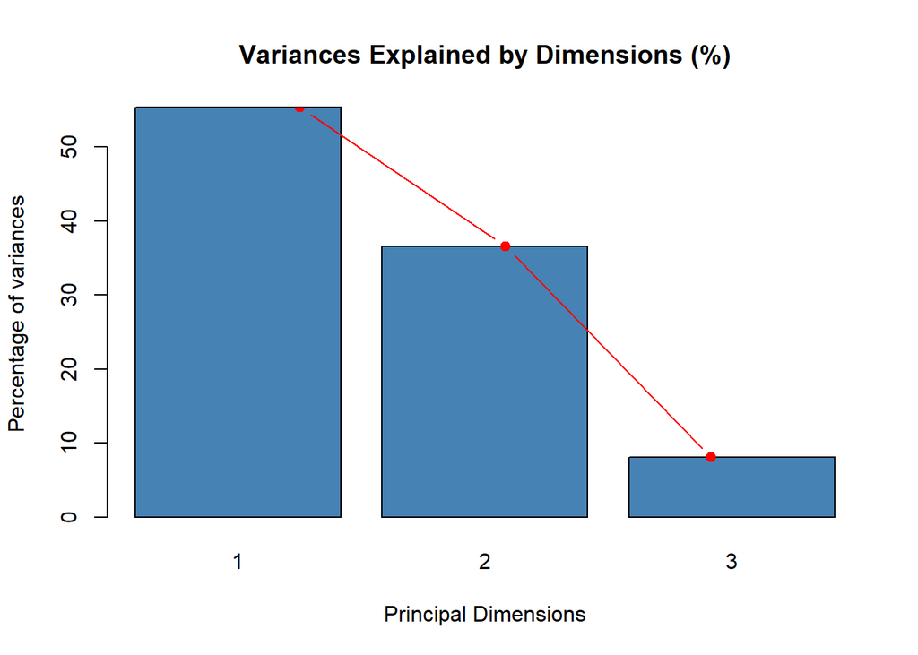

```r
barplot(eig.val[, 2],
        names.arg = 1:nrow(eig.val),
        main = "Variances Explained by Dimensions (%)",
        xlab = "Principal Dimensions",
        ylab = "Percentage of variances",
        col ="steelblue")

lines(x = 1:nrow(eig.val), eig.val[, 2],
      type = "b", pch = 19, col = "red")
```

**Le taux d’inertie cumulé du premier plan étant de 91.949%, il est clair que l’on doit se contenter des 2 premiers axes.**

## 6. Représentation et interprétation de la carte des profils-colonnes:

```r
round(cbind(res.ca$col$coord[,1:2],res.ca$col$contrib[,1:2], res.ca$col$cos2[,1:2]),2)
```

```
##          Dim 1 Dim 2 Dim 1 Dim 2 Dim 1 Dim 2
## café      0.32 -0.17 27.03 11.68  0.77  0.22
## cafébar   1.11  0.12 20.91  0.36  0.93  0.01
## cafémx   -0.62 -0.29 49.22 16.75  0.80  0.18
## caféres  -0.20  0.96  1.71 60.05  0.04  0.88
## salonthé -0.07  0.19  1.13 11.16  0.07  0.46
```

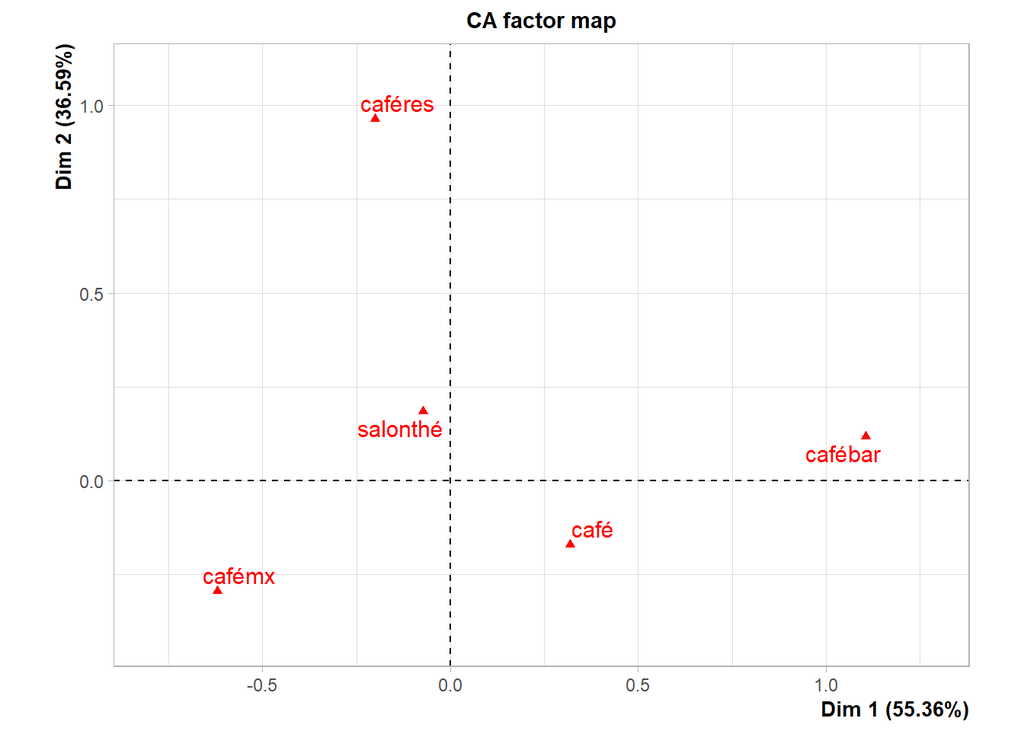

```r
plot(res.ca, invisible="row")
```

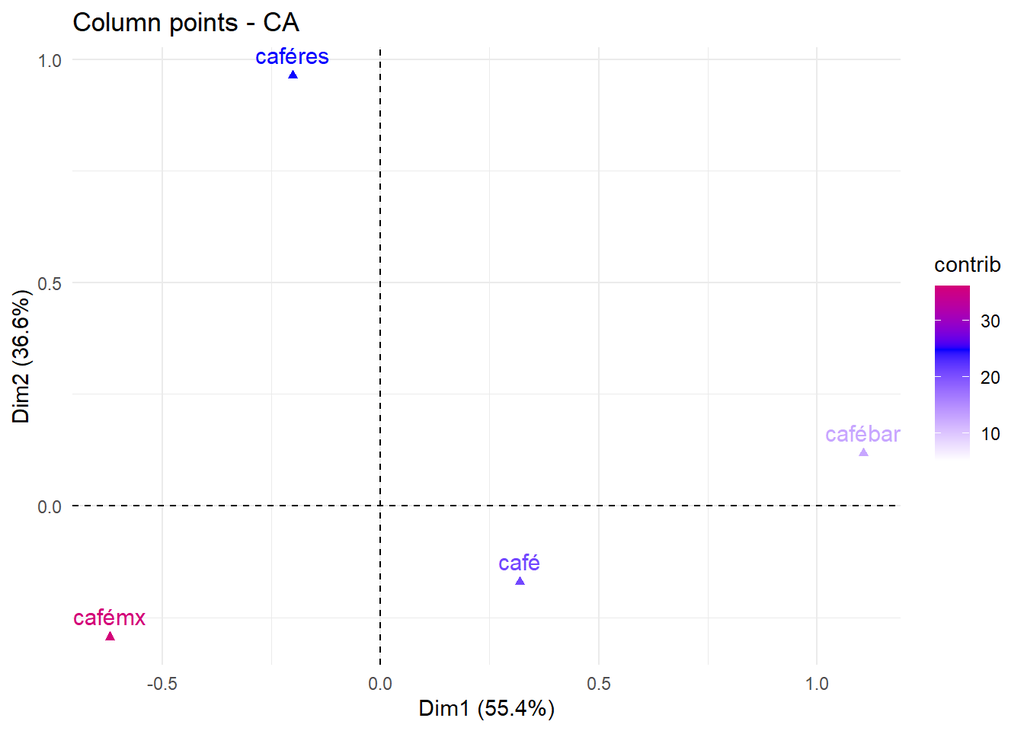

```r
fviz_ca_col(res.ca, col.col = "contrib")+
 scale_color_gradient2(low = "white", mid = "blue",
           high = "red", midpoint = 25) +
 theme_minimal()
```

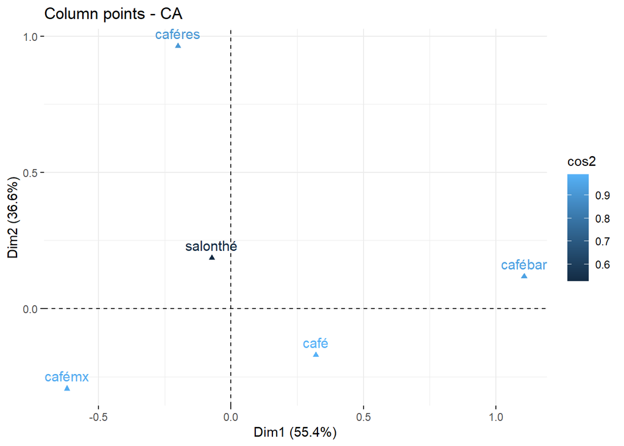

```r
fviz_ca_col(res.ca, col.col="cos2")
```

## 7. Représentation et interprétation de la carte des profils-lignes :

```r
round(cbind(res.ca$row$coord[,1:2],res.ca$row$contrib[,1:2], res.ca$row$cos2[,1:2]),2)
```

```
##                            Dim 1 Dim 2 Dim 1 Dim 2 Dim 1 Dim 2
## Chaque jour                 0.64 -0.33 45.28 18.01  0.75  0.20
## Le Weekend                  0.22  0.40  9.80 50.09  0.22  0.75
## Les jours fériés           -0.52  0.16 32.60  4.42  0.77  0.07
## Quelques jours par semaine -0.23 -0.28 12.32 27.48  0.36  0.53
```

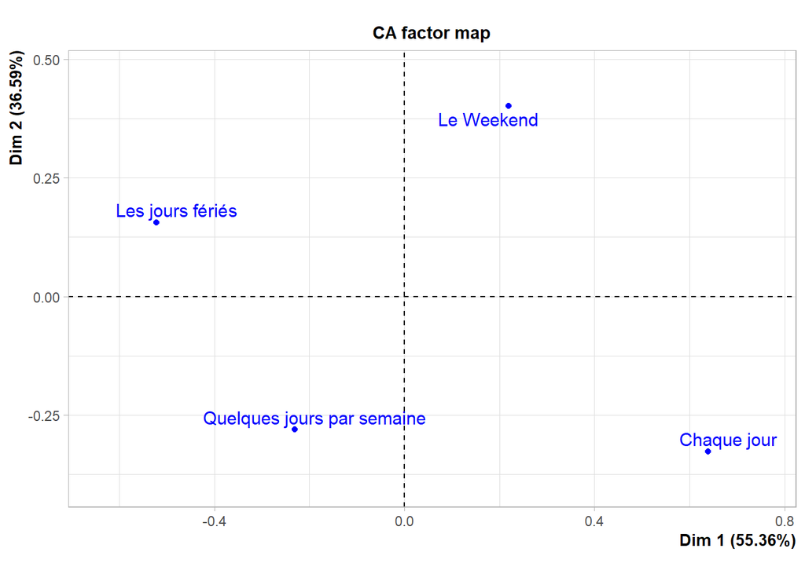

```r
plot(res.ca, invisible="col")
```

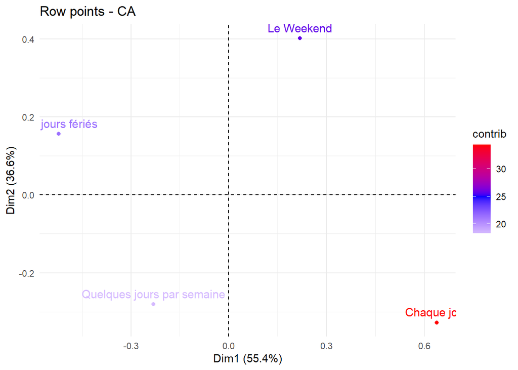

```r
fviz_ca_row(res.ca, col.row = "contrib")+
 scale_color_gradient2(low = "white", mid = "blue",
           high = "red", midpoint = 25) +
 theme_minimal()
```

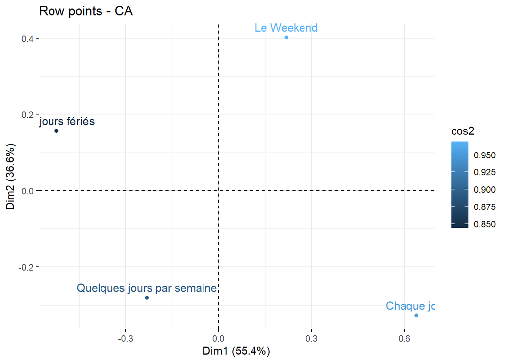

```r
fviz_ca_row(res.ca, col.row = "cos2")
```